# Part 2: Leveraging Machine Learning and Hyperspectral Imaging for Predicting Adulteration in Ground Arabica Coffee with Robusta: Principal Component Analysis and Clustering

#### Confusion Matrix - Raw Spectra

```r
# Make labels for the confusion matrix table
class_no <- as.factor(hsi_raw$binary_class) #select the binary class column and convert to a factor
table(class_no) # confirm the number per class
```

```
class_no
 adulterated pure_arabica
        1394           75
```

```r
class_k <- ifelse(class_no == 'adulterated',1, 2) # assign numbers to the groups

# Create a confusion matrix
cfmatrix_raw<-confusionMatrix(as.factor(raw_clusters),as.factor(class_k))

cfmatrix_raw #display the confusion matrix
```

```
Confusion Matrix and Statistics

          Reference
Prediction   1   2
         1 706   0
         2 688  75

               Accuracy : 0.5317
                 95% CI : (0.5058, 0.5574)
    No Information Rate : 0.9489
    P-Value [Acc > NIR] : 1

                  Kappa : 0.0948

 Mcnemar's Test P-Value : <2e-16

            Sensitivity : 0.5065
            Specificity : 1.0000
         Pos Pred Value : 1.0000
         Neg Pred Value : 0.0983
             Prevalence : 0.9489
         Detection Rate : 0.4806
   Detection Prevalence : 0.4806
      Balanced Accuracy : 0.7532

       'Positive' Class : 1
```

```r
kable(cfmatrix_raw$byClass)
```

|  | x |
| --- | --- |
| Sensitivity | 0.5064562 |
| Specificity | 1.0000000 |
| Pos Pred Value | 1.0000000 |
| Neg Pred Value | 0.0982962 |
| Precision | 1.0000000 |
| Recall | 0.5064562 |
| F1 | 0.6723810 |
| Prevalence | 0.9489449 |
| Detection Rate | 0.4805990 |
| Detection Prevalence | 0.4805990 |
| Balanced Accuracy | 0.7532281 |

### Standard Normal Variate (SNV) Spectral Data

#### PCA Analysis: SNV pre-treated data

```r
pca_snv <- PCA(hsi_snv[,c(6:229)],ncp = 5, graph = FALSE)

pca_snv$eig[1:5,] # Extract the first 5 component eigenvalues
```

```
        eigenvalue percentage of variance cumulative percentage of variance
comp 1 197.3480795             88.1018212                          88.10182
comp 2  19.0827700              8.5190938                          96.62091
comp 3   6.2034840              2.7694125                          99.39033
comp 4   0.6399516              0.2856927                          99.67602
comp 5   0.3010730              0.1344076                          99.81043
```

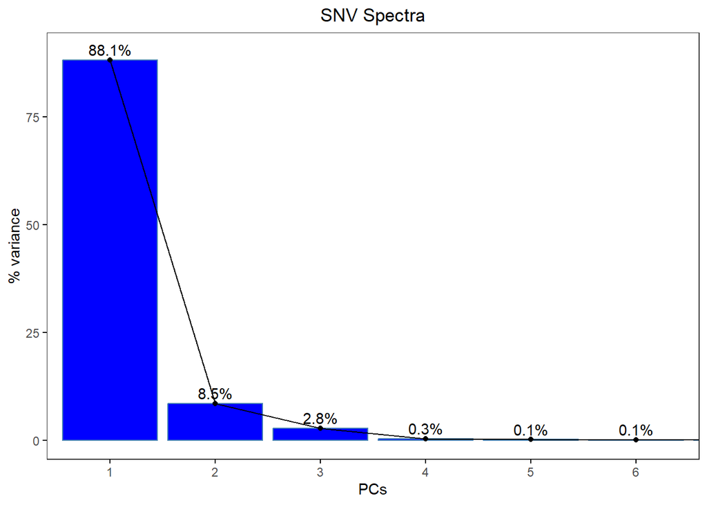

```r
# Scree Plot: Check the number of components to keep

fviz_eig(pca_snv, addlabels = TRUE, ylim = c(0, 90),
         xlim=c(1,6), main = 'SNV Spectra',barfill = "blue",
         hjust = 0.5,
         ggtheme = theme_bw(),xlab = "PCs", ylab = "% variance")+
  theme(plot.title = element_text(hjust = 0.5))+
  theme(panel.grid = element_blank())
```

```r
# Save the PCs in a new data frame
Pcs_hsi_snv <- as.data.frame(pca_snv$ind$coord[,c(1:5)])
colnames(Pcs_hsi_snv) <- c("PC1","PC2","PC3","PC4","PC5")
Pcs_hsi_snv <- cbind(columns, Pcs_hsi_snv) # Bind with the columns from initial data--> with sample details
kable(head(Pcs_hsi_snv))
```

| sample_id | binary_class | three_class | adult_percent | cal_val | PC1 | PC2 | PC3 | PC4 | PC5 |
| --- | --- | --- | --- | --- | --- | --- | --- | --- | --- |
| Pure_Arabica_10 | pure_arabica | pure_arabica | 0 | 1 | -10.92845 | 0.0692437 | 3.032866 | 1.4293193 | -0.5953577 |
| Pure_Arabica_3 | pure_arabica | pure_arabica | 0 | 1 | -21.17899 | -4.4378327 | 2.244970 | 0.6628035 | -0.9083175 |
| Pure_Arabica_2 | pure_arabica | pure_arabica | 0 | 1 | -13.47325 | -0.7823829 | 2.137894 | 1.8928154 | -0.5392647 |
| Pure_Arabica_2 | pure_arabica | pure_arabica | 0 | 1 | -13.13640 | -0.1849247 | 2.077591 | 1.9630751 | -0.9788448 |
| Pure_Arabica_2 | pure_arabica | pure_arabica | 0 | 1 | -14.32925 | -0.8975206 | 2.268559 | 1.6703217 | -0.5710557 |
| Pure_Arabica_25 | pure_arabica | pure_arabica | 0 | 2 | -15.41867 | -1.5177495 | 2.502160 | 1.7023439 | -0.8283131 |

```r
#write.csv(Pcs_hsi_snv, file = "pcs_hsi_snv.csv", row.names = FALSE) #save PC data
```

**Insights: PCA-SNV spectral treatment**

- The first two principal components, **PC1 and PC2**, account for the most the variance (**96.6%**).

#### **PCA Plot for SNV Spectra**

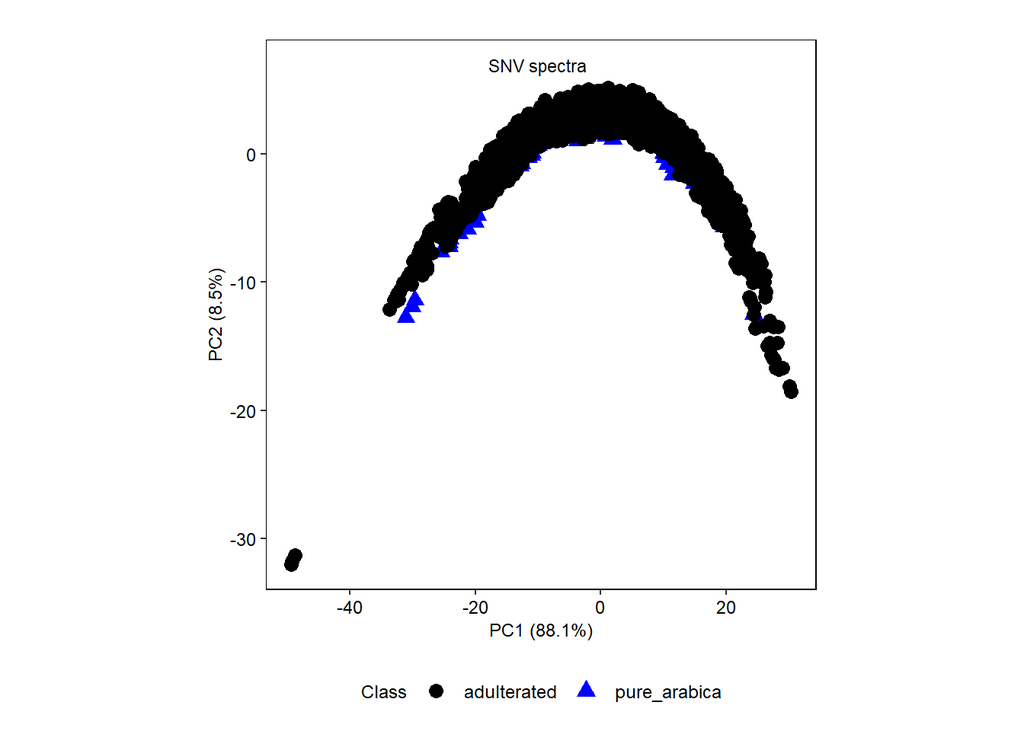

```r
# SNV spectra PCA Plot

Pcs_hsi_snv %>%
  ggplot(mapping = aes(x = PC1, y = PC2,
                       shape = as.factor(binary_class), color = binary_class)) +
  geom_point(size= 3) +
  labs(x = "PC1 (88.1%)", y = "PC2 (8.5%)",
       title = "",shape = "Class", color = "Class") +
  theme_bw() +
  theme(
    panel.border = element_rect(color = 'black', fill = NA),
    panel.grid = element_blank(),
    axis.text.x = element_text(color = 'black', size = 9),
    axis.text.y = element_text(color = 'black', size = 9),
    aspect.ratio = 1,
    axis.title.x = element_text(size = 9),
    axis.title.y = element_text(size = 9),
    plot.title = element_text(size = 9, hjust = 0.5),
    legend.title = element_text(size = 9),
    legend.text = element_text(size = 9),
    legend.position = "bottom"
  ) +
  scale_color_manual(values = c("pure_arabica" = "blue", "adulterated" = "black")) +
   annotate("text", x = -10, y = 7, label = "SNV spectra", size = 3, color = "black")
```

#### Check Important variables contributing to PC1 and PC2 for HSI SNV Spectra

```r
# Let us extract the loadings from the PCA
loadings <- pca_snv$var$coord

# Sort the loadings for PC1 and PC2
top_PC1 <- head(sort(abs(loadings[, 1]), decreasing = TRUE), 10) # Top 10 for PC1
top_PC2 <- head(sort(abs(loadings[, 2]), decreasing = TRUE), 10)  # Top 10 for PC2

# Combine into a data frame for easy viewing
top_PC1 <- as.data.frame(top_PC1)
top_PC2 <- as.data.frame(top_PC2)

# Display the top contributing variables
kable(top_PC1)
```

|  | top_PC1 |
| --- | --- |
| X1548.97998 | 0.9976597 |
| X1552.530029 | 0.9976566 |
| X1545.420044 | 0.9976289 |
| X1556.089966 | 0.9975457 |
| X1541.869995 | 0.9975425 |
| X1538.319946 | 0.9974280 |
| X1559.640015 | 0.9974233 |
| X1534.76001 | 0.9973988 |
| X1531.209961 | 0.9972933 |
| X1563.199951 | 0.9972036 |

```r
kable(top_PC2)
```

|  | top_PC2 |
| --- | --- |
| X1347.300049 | 0.9469037 |
| X1343.780029 | 0.9463100 |
| X1340.26001 | 0.9240159 |
| X1350.819946 | 0.9189437 |
| X1336.73999 | 0.8868445 |
| X1354.349976 | 0.8647280 |
| X1333.219971 | 0.8431986 |
| X1329.699951 | 0.7981270 |
| X1357.869995 | 0.7981151 |
| X1326.180054 | 0.7539149 |

- Similar to the raw spectra, spectral range of **1531 to 1563 nm*** and **1326 nm to 1357 nm**, contribute to vast of the variance in PC1 and PC2, respectively.

#### K-Means Clustering: SNV Spectra

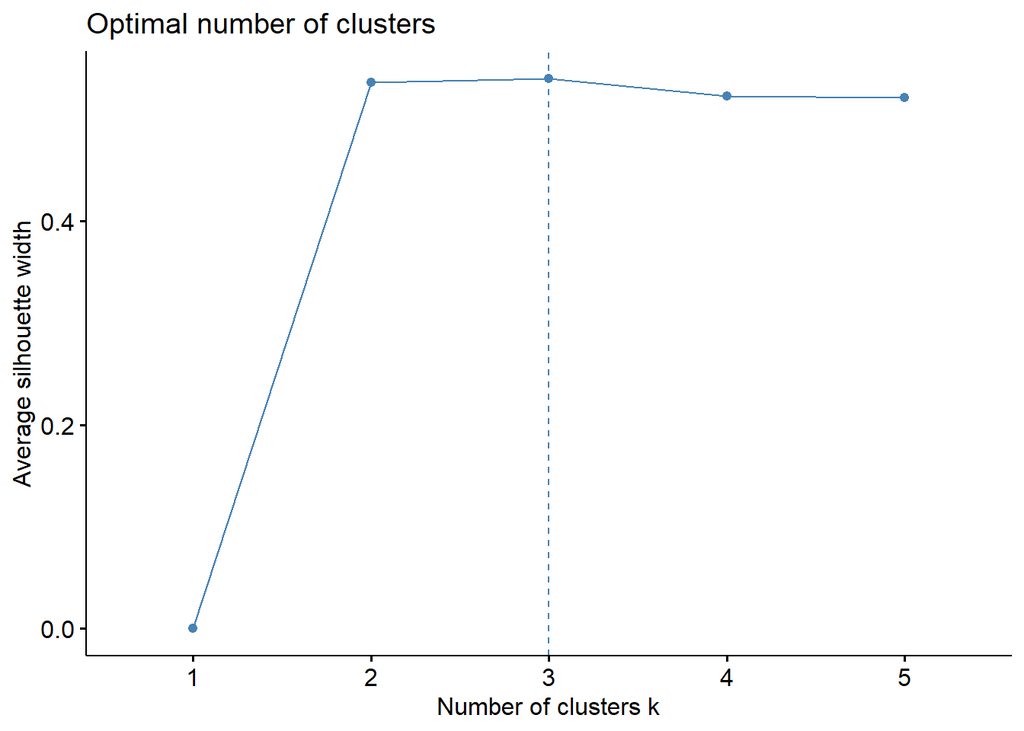

```r
# Use PCA reduced data to first determine the number of clusters  by silhouette method

# optimal number of clusters for HSI
snv_clust<-fviz_nbclust(Pcs_hsi_snv[,c(6,7)],
                        kmeans, method = "silhouette", k.max=5)

# Optimal number of cluster selected by kmeans = 3
print(snv_clust) #determine the number of clusters
```

```r
# Perform K-Means Classification using the optimal number of clusters
snv_kmeans <- kmeans(Pcs_hsi_snv[,c(6,7)],centers = 2, nstart = 25)
snv_clusters <- as.factor(snv_kmeans$cluster) # Extract clusters
```

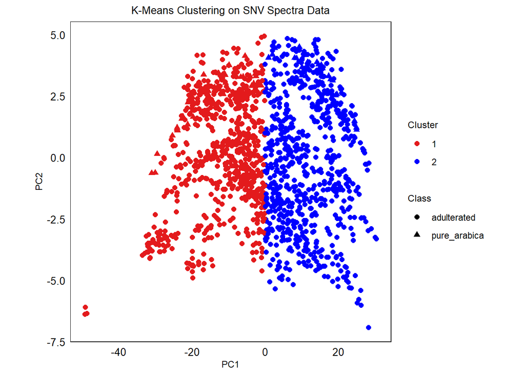

```r
# Add the cluster assignments to the data frame
Pcs_hsi_snv$Cluster <- snv_clusters

# Visualize the clusters
ggplot(Pcs_hsi_snv, aes(x = PC1, y = PC3, color = Cluster, shape = as.factor(binary_class))) +
  geom_point(size = 2) +
  labs(x = "PC1", y = "PC2", title = "K-Means Clustering on SNV Spectra Data", shape = 'Class') +
 scale_color_manual(values = c("#e31a1c","blue")) +
  theme_minimal() +
  theme(panel.border = element_rect(color = 'black', fill = NA),
        panel.grid = element_blank(),
        axis.text.x = element_text(color = 'black', size = 10),
        axis.text.y = element_text(color = 'black', size = 10),
        aspect.ratio = 1,
        axis.title.x = element_text(size = 9),
        axis.title.y = element_text(size = 9),
        legend.title = element_text(size = 9),
        plot.title = element_text(size = 10, hjust = 0.5))
```

#### Confusion Matrix - SNV Spectra

```r
# Create a confusion matrix
cfmatrix_snv<-confusionMatrix(as.factor(snv_clusters),as.factor(class_k))

cfmatrix_snv #display the confusion matrix
```

```
Confusion Matrix and Statistics

          Reference
Prediction   1   2
         1 679  44
         2 715  31

               Accuracy : 0.4833
                 95% CI : (0.4575, 0.5092)
    No Information Rate : 0.9489
    P-Value [Acc > NIR] : 1

                  Kappa : -0.019

 Mcnemar's Test P-Value : <2e-16

            Sensitivity : 0.48709
            Specificity : 0.41333
         Pos Pred Value : 0.93914
         Neg Pred Value : 0.04155
             Prevalence : 0.94894
         Detection Rate : 0.46222
   Detection Prevalence : 0.49217
      Balanced Accuracy : 0.45021

       'Positive' Class : 1
```

```r
kable(cfmatrix_snv$byClass)
```

|  | x |
| --- | --- |
| Sensitivity | 0.4870875 |
| Specificity | 0.4133333 |
| Pos Pred Value | 0.9391425 |
| Neg Pred Value | 0.0415550 |
| Precision | 0.9391425 |
| Recall | 0.4870875 |
| F1 | 0.6414738 |
| Prevalence | 0.9489449 |
| Detection Rate | 0.4622192 |
| Detection Prevalence | 0.4921715 |
| Balanced Accuracy | 0.4502104 |

### Standard Normal Variate (SNV), Savitzky_Golay and 1st Derivative Spectral Data

#### PCA Analysis: SNV+SG+1D pre-treated data

```r
pca_snv_sg_1d <- PCA(hsi_snv_1d[,c(6:229)],ncp = 10, graph = FALSE)

pca_snv_sg_1d$eig[1:5,] # Extract the first 5 component eigenvalues
```

```
       eigenvalue percentage of variance cumulative percentage of variance
comp 1  99.175475              44.274766                          44.27477
comp 2  59.157127              26.409432                          70.68420
comp 3  34.743219              15.510365                          86.19456
comp 4  13.801326               6.161306                          92.35587
comp 5   6.301664               2.813243                          95.16911
```

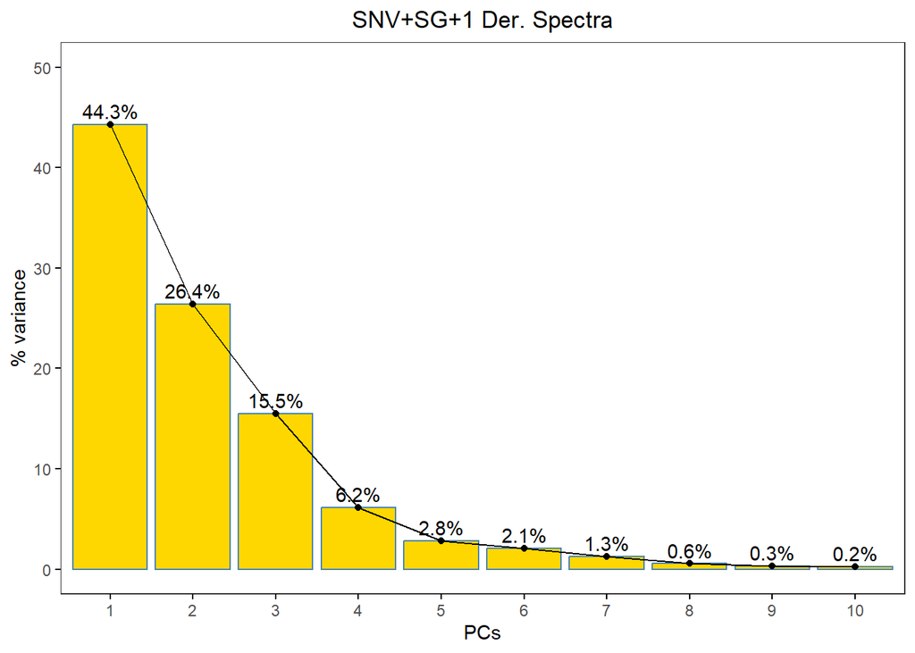

```r
# Scree Plot: Check the number of components to keep

fviz_eig(pca_snv_sg_1d, addlabels = TRUE, ylim = c(0, 50),
         xlim=c(1,10), main = 'SNV+SG+1 Der. Spectra',barfill = "gold",
         hjust = 0.5,
         ggtheme = theme_bw(),xlab = "PCs", ylab = "% variance")+
  theme(plot.title = element_text(hjust = 0.5))+
  theme(panel.grid = element_blank())
```

```r
# Save the PCs in a new data frame
Pcs_hsi_snv_sg_1d <- as.data.frame(pca_snv_sg_1d$ind$coord[,c(1:10)])
colnames(Pcs_hsi_snv_sg_1d) <- c("PC1","PC2","PC3","PC4","PC5","PC6","PC7","PC8","PC9","PC10")
Pcs_hsi_snv_sg_1d <- cbind(columns, Pcs_hsi_snv_sg_1d) # Bind with the columns from initial data--> with sample details
kable(head(Pcs_hsi_snv_sg_1d))
```

| sample_id | binary_class | three_class | adult_percent | cal_val | PC1 | PC2 | PC3 | PC4 | PC5 | PC6 | PC7 | PC8 | PC9 | PC10 |
| --- | --- | --- | --- | --- | --- | --- | --- | --- | --- | --- | --- | --- | --- | --- |
| Pure_Arabica_10 | pure_arabica | pure_arabica | 0 | 1 | 7.816656 | -7.249043 | 4.4910550 | 9.475175 | -1.1425585 | 1.7232719 | -0.1841188 | 0.8188065 | -0.5044184 | -0.6442594 |
| Pure_Arabica_3 | pure_arabica | pure_arabica | 0 | 1 | 12.807400 | -10.541332 | -4.1325183 | 9.525875 | -4.7286674 | 0.4647610 | -2.3251021 | -0.1466754 | -0.2077274 | 0.2019364 |
| Pure_Arabica_2 | pure_arabica | pure_arabica | 0 | 1 | 8.763490 | -6.795419 | 1.4471280 | 13.189943 | -1.0560332 | -0.6607998 | -0.0106254 | -0.5297897 | -0.7921356 | 0.2192439 |
| Pure_Arabica_2 | pure_arabica | pure_arabica | 0 | 1 | 9.057916 | -5.966264 | 1.3586940 | 13.678044 | -1.8788869 | -0.0782885 | 0.7672993 | -1.2641845 | -0.8828598 | -0.4145448 |
| Pure_Arabica_2 | pure_arabica | pure_arabica | 0 | 1 | 9.434077 | -6.938138 | 1.0048629 | 11.198098 | -0.6455951 | -0.1624955 | 0.2476426 | -0.9475997 | -0.3875612 | -0.4600112 |
| Pure_Arabica_25 | pure_arabica | pure_arabica | 0 | 2 | 10.012251 | -8.053628 | 0.4709614 | 12.676888 | -2.5559122 | -0.1665541 | 0.1316101 | 0.2605244 | -1.9317110 | -0.1974192 |

```r
#write.csv(Pcs_hsi_snv_sg_1d, file = "pcs_hsi_snv_sg_1d.csv", row.names = FALSE) #save PC data
```

**Insights: PCA-SNV+SG+1D spectral treatment**

- The first four principal components account for 92.4% of the variation in the data.

#### **PCA Plot for SNV+SG+1D Spectra**

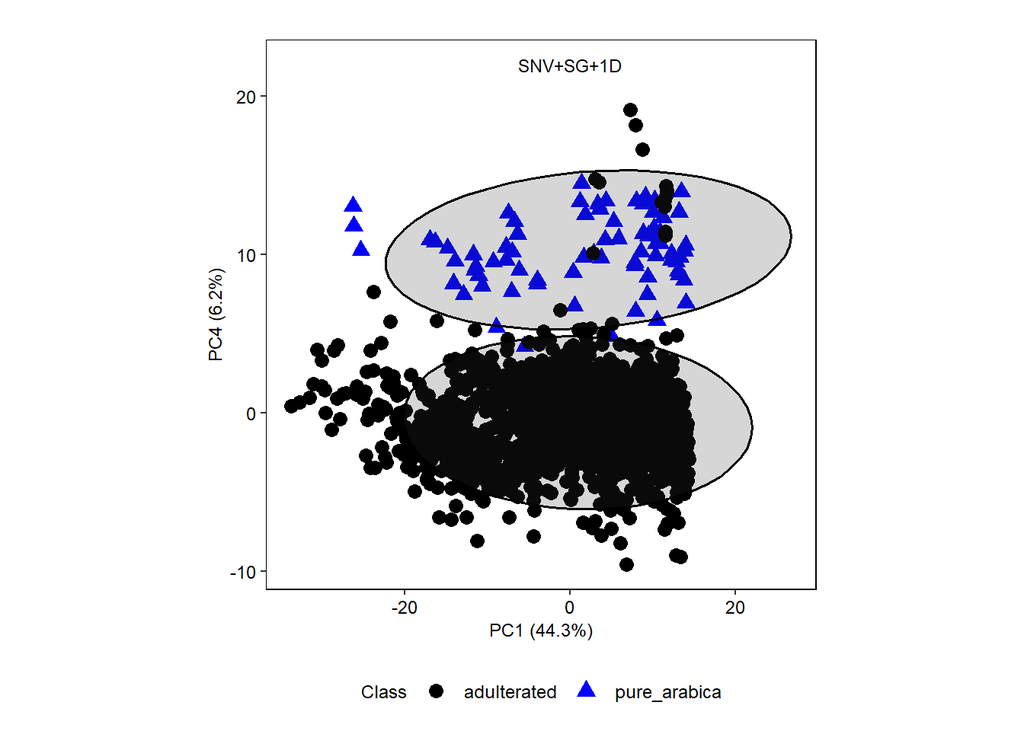

```r
# SNV+SG+1D spectra PCA Plot

Pcs_hsi_snv_sg_1d %>%
  ggplot(mapping = aes(x = PC1, y = PC4,
                       shape = as.factor(binary_class), color = binary_class)) +
  geom_point(size=3) +
  labs(x = "PC1 (44.3%)", y = "PC4 (6.2%)",
       title = "",shape = "Class", color = "Class") +
  theme_bw() +
  theme(
    panel.border = element_rect(color = 'black', fill = NA),
    panel.grid = element_blank(),
    axis.text.x = element_text(color = 'black', size = 9),
    axis.text.y = element_text(color = 'black', size = 9),
    aspect.ratio = 1,
    axis.title.x = element_text(size = 9),
    axis.title.y = element_text(size = 9),
    plot.title = element_text(size = 9, hjust = 0.5),
    legend.title = element_text(size = 9),
    legend.text = element_text(size = 9),
    legend.position = "bottom"
  ) +
  stat_ellipse(aes(group = binary_class),
               level = 0.95,
               geom = "polygon", alpha = 0.2,
               color = 'black', linewidth = 0.6)+
  scale_color_manual(values = c("pure_arabica" = "blue", "adulterated" = "black")) +
   annotate("text", x = 0, y = 22, label = "SNV+SG+1D", size = 3, color = "black")
```

#### Check Important variables contributing to PC1 and PC2 for HSI SNV+SG+1st Derivative Spectra

```r
# Let us extract the loadings from the PCA
loadings <- pca_snv_sg_1d$var$coord

# Sort the loadings for PC1 and PC2
top_PC1 <- head(sort(abs(loadings[, 1]), decreasing = TRUE), 10) # Top 10 for PC1
top_PC2 <- head(sort(abs(loadings[, 2]), decreasing = TRUE), 10)  # Top 10 for PC2

# Combine into a data frame for easy viewing
top_PC1 <- as.data.frame(top_PC1)
top_PC2 <- as.data.frame(top_PC2)

# Display the top contributing variables
kable(top_PC1)
```

|  | top_PC1 |
| --- | --- |
| X1143.959961 | 0.9840986 |
| X1140.469971 | 0.9824947 |
| X1147.449951 | 0.9807038 |
| X1276.969971 | 0.9801263 |
| X1273.459961 | 0.9798308 |
| X1280.47998 | 0.9785021 |
| X1269.949951 | 0.9782354 |
| X1136.98999 | 0.9753663 |
| X1266.439941 | 0.9751961 |
| X1283.98999 | 0.9751264 |

```r
kable(top_PC2)
```

|  | top_PC2 |
| --- | --- |
| X1573.869995 | 0.9817624 |
| X1570.310059 | 0.9779056 |
| X1577.430054 | 0.9735114 |
| X1566.75 | 0.9680412 |
| X1563.199951 | 0.9572951 |
| X1559.640015 | 0.9472885 |
| X1580.98999 | 0.9382606 |
| X1556.089966 | 0.9379681 |
| X1552.530029 | 0.9310056 |
| X1548.97998 | 0.9277183 |

- According to the x-loadings, Spectral wavelengths in the regions **1136-1147 nm**, and **1266 nm to 1283 nm** contribute to the variance in PC1. On the other hand, the vast of the variation in PC2 is contributed by regions **1548 nm to 1580 nm**.

#### K-Means Clustering: SNV+SG+1st Derivative Spectra

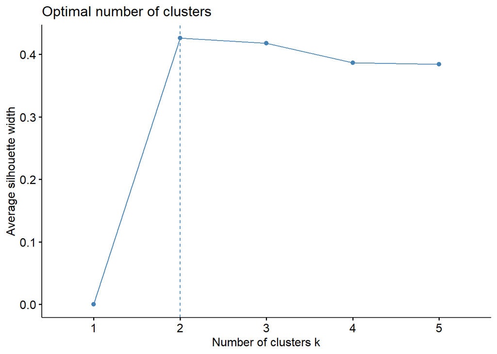

```r
# Use PCA reduced data to first determine the number of clusters  by silhouette method

# optimal number of clusters for HSI
snv_sg_1d_clust<-fviz_nbclust(Pcs_hsi_snv_sg_1d[,c(6,7)],
                        kmeans, method = "silhouette", k.max=5)

print(snv_sg_1d_clust) #determine the number of clusters
```

```r
# Perform K-Means Classification using the optimal number of clusters
snv_sg_1d_kmeans <- kmeans(Pcs_hsi_snv_sg_1d[,c(6,7)], centers = 2, nstart = 25)
snv_sg_1d_clusters <- as.factor(snv_sg_1d_kmeans$cluster) # Extract clusters
```

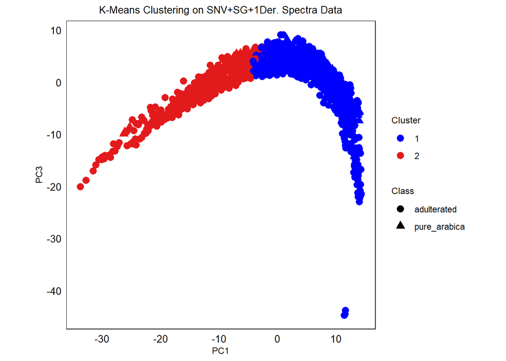

```r
# Add the cluster assignments to the data frame
Pcs_hsi_snv_sg_1d$Cluster <- snv_sg_1d_clusters

# Visualize the clusters
ggplot(Pcs_hsi_snv_sg_1d, aes(x = PC1, y = PC3, color = Cluster, shape = as.factor(binary_class))) +
  geom_point(size = 3) +
  labs(x = "PC1", y = "PC3", title = "K-Means Clustering on SNV+SG+1Der. Spectra Data", shape = 'Class') +
 scale_color_manual(values = c("blue", "#e31a1c")) +
  theme_minimal() +
  theme(panel.border = element_rect(color = 'black', fill = NA),
        panel.grid = element_blank(),
        axis.text.x = element_text(color = 'black', size = 10),
        axis.text.y = element_text(color = 'black', size = 10),
        aspect.ratio = 1,
        axis.title.x = element_text(size = 9),
        axis.title.y = element_text(size = 9),
        legend.title = element_text(size = 9),
        plot.title = element_text(size = 10, hjust = 0.5))
```

#### Confusion Matrix - SNV+SG+1D Spectra

```r
# Create a confusion matrix
cfmatrix_snv_sg_1d<-confusionMatrix(as.factor(snv_sg_1d_clusters),as.factor(class_k))

cfmatrix_snv_sg_1d #display the confusion matrix
```

```
Confusion Matrix and Statistics

          Reference
Prediction   1   2
         1 961  48
         2 433  27

               Accuracy : 0.6726
                 95% CI : (0.6479, 0.6965)
    No Information Rate : 0.9489
    P-Value [Acc > NIR] : 1

                  Kappa : 0.0144

 Mcnemar's Test P-Value : <2e-16

            Sensitivity : 0.6894
            Specificity : 0.3600
         Pos Pred Value : 0.9524
         Neg Pred Value : 0.0587
             Prevalence : 0.9489
         Detection Rate : 0.6542
   Detection Prevalence : 0.6869
      Balanced Accuracy : 0.5247

       'Positive' Class : 1
```

```r
kable(cfmatrix_snv_sg_1d$byClass)
```

|  | x |
| --- | --- |
| Sensitivity | 0.6893831 |
| Specificity | 0.3600000 |
| Pos Pred Value | 0.9524281 |
| Neg Pred Value | 0.0586957 |
| Precision | 0.9524281 |
| Recall | 0.6893831 |
| F1 | 0.7998335 |
| Prevalence | 0.9489449 |
| Detection Rate | 0.6541865 |
| Detection Prevalence | 0.6868618 |
| Balanced Accuracy | 0.5246915 |

### Standard Normal Variate (SNV), Savitzky_Golay and 2nd Derivative Spectral Data

#### PCA Analysis: SNV+SG+2D pre-treated data

```r
pca_snv_sg_2d <- PCA(hsi_snv_2d[,c(6:229)],ncp = 50, graph = FALSE)

pca_snv_sg_2d$eig[1:50,] # Extract the first 5 component eigenvalues
```

```
         eigenvalue percentage of variance cumulative percentage of variance
comp 1  99.79195521            44.54998001                          44.54998
comp 2  55.73163021            24.88019206                          69.43017
comp 3  28.22255368            12.59935432                          82.02953
comp 4  12.64085330             5.64323808                          87.67276
comp 5   5.08994917             2.27229874                          89.94506
comp 6   4.43325826             1.97913315                          91.92420
comp 7   2.46040577             1.09839543                          93.02259
comp 8   2.07181388             0.92491691                          93.94751
comp 9   1.96506015             0.87725899                          94.82477
comp 10  1.31491285             0.58701466                          95.41178
comp 11  0.99850436             0.44576088                          95.85754
comp 12  0.91175266             0.40703244                          96.26458
comp 13  0.80113423             0.35764921                          96.62222
comp 14  0.75571210             0.33737147                          96.95960
comp 15  0.62943043             0.28099573                          97.24059
comp 16  0.53595949             0.23926763                          97.47986
comp 17  0.49454487             0.22077896                          97.70064
comp 18  0.44144627             0.19707423                          97.89771
comp 19  0.37781196             0.16866605                          98.06638
comp 20  0.33265309             0.14850584                          98.21488
comp 21  0.32517360             0.14516678                          98.36005
comp 22  0.31494294             0.14059953                          98.50065
comp 23  0.29039349             0.12963995                          98.63029
comp 24  0.24971028             0.11147780                          98.74177
comp 25  0.22095142             0.09863903                          98.84041
comp 26  0.19729152             0.08807657                          98.92848
comp 27  0.17644570             0.07877040                          99.00725
comp 28  0.14806544             0.06610064                          99.07336
comp 29  0.14382659             0.06420830                          99.13756
comp 30  0.13080471             0.05839496                          99.19596
comp 31  0.11748936             0.05245061                          99.24841
comp 32  0.11549756             0.05156141                          99.29997
comp 33  0.10467121             0.04672822                          99.34670
comp 34  0.09184069             0.04100031                          99.38770
comp 35  0.08976135             0.04007203                          99.42777
comp 36  0.08325133             0.03716577                          99.46494
comp 37  0.07449675             0.03325748                          99.49819
comp 38  0.06991812             0.03121345                          99.52941
comp 39  0.05883016             0.02626346                          99.55567
comp 40  0.05733964             0.02559805                          99.58127
comp 41  0.05282051             0.02358058                          99.60485
comp 42  0.05122582             0.02286867                          99.62772
comp 43  0.04810602             0.02147590                          99.64919
comp 44  0.04408047             0.01967878                          99.66887
comp 45  0.04367733             0.01949881                          99.68837
comp 46  0.03960714             0.01768176                          99.70605
comp 47  0.03601857             0.01607972                          99.72213
comp 48  0.03439203             0.01535358                          99.73749
comp 49  0.03314331             0.01479612                          99.75228
comp 50  0.02919453             0.01303327                          99.76532
```

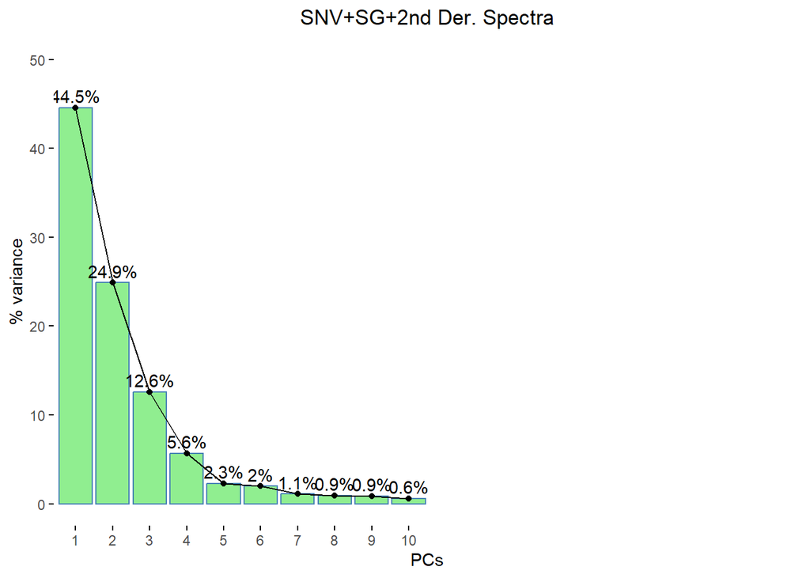

```r
# Scree Plot: Check the number of components to keep

fviz_eig(pca_snv_sg_2d, addlabels = TRUE, ylim = c(0, 50),
         xlim=c(1,20), main = 'SNV+SG+2nd Der. Spectra',barfill = "lightgreen",
         hjust = 0.5,xlab = "PCs", ylab = "% variance")+
  theme(plot.title = element_text(hjust = 0.5))+
  theme(panel.grid = element_blank())
```

```r
# Save the PCs in a new data frame
Pcs_hsi_snv_sg_2d <- as.data.frame(pca_snv_sg_2d$ind$coord[,c(1:50)])
colnames(Pcs_hsi_snv_sg_2d) <- c("PC1","PC2","PC3","PC4","PC5",
                                 "PC6","PC7","PC8","PC9","PC10",
                                 "PC11","PC12","PC13","PC14","PC15",
                                 "PC16","PC17","PC18","PC19","PC20",
                                 "P21","P22","P23","P24","PC25",
                                 "P26","PC27","PC28","PC29","PC30",
                                 "PC31","PC32","PC33","PC34","PC35",
                                 "PC36","PC37","PC38","PC39","PC40",
                                 "PC41","PC42","PC43","PC44","PC45",
                                 "PC46","PC47","PC48","PC49","PC50")
Pcs_hsi_snv_sg_2d <- cbind(columns, Pcs_hsi_snv_sg_2d) # Bind with the columns from initial data--> with sample details
kable(head(Pcs_hsi_snv_sg_2d))
```

| sample_id | binary_class | three_class | adult_percent | cal_val | PC1 | PC2 | PC3 | PC4 | PC5 | PC6 | PC7 | PC8 | PC9 | PC10 | PC11 | PC12 | PC13 | PC14 | PC15 | PC16 | PC17 | PC18 | PC19 | PC20 | P21 | P22 | P23 | P24 | PC25 | … |
| --- | --- | --- | --- | --- | --- | --- | --- | --- | --- | --- | --- | --- | --- | --- | --- | --- | --- | --- | --- | --- | --- | --- | --- | --- | --- | --- | --- | --- | --- | --- |
| Pure_Arabica_10 | pure_arabica | pure_arabica | 0 | 1 | -4.1719257 | 12.50206 | 12.60210 | 0.9371088 | 0.5776230 | -1.6748438 | 0.8498265 | 1.0003742 | -0.7917290 | -1.9593612 | -0.2920530 | 0.4915434 | -1.0195620 | -1.0104332 | 0.3867839 | 0.2024238 | 0.2529023 | 0.3849003 | 0.0780074 | -0.5204604 | 0.9949721 | -0.8075556 | -0.1002033 | -0.5648954 | 0.9660863 | … |
| Pure_Arabica_3 | pure_arabica | pure_arabica | 0 | 1 | 3.7379458 | 15.96940 | 14.78799 | -3.5886841 | 0.5641214 | -0.9066720 | 0.8456390 | -1.5370920 | 0.1475861 | 0.1038220 | -0.5351278 | -0.9668433 | -2.2546085 | -1.3139294 | 0.6209242 | 1.9138879 | -0.8666611 | 0.1016141 | -0.9909178 | 0.1858010 | 0.6381573 | 0.0289026 | 0.0739298 | -0.4632830 | 0.4921191 | … |
| Pure_Arabica_2 | pure_arabica | pure_arabica | 0 | 1 | -0.7500140 | 13.79452 | 17.61945 | 0.5415258 | -1.0113074 | 0.0119761 | 0.9639738 | 0.3556521 | -0.7999887 | -0.5515792 | 0.9649239 | 1.0227083 | -0.7131355 | -1.2853786 | -0.4255310 | -0.2757902 | 0.1324300 | -0.4618626 | 1.2255915 | 1.0957964 | -0.6090460 | -0.6384991 | 0.1993172 | -0.1638496 | 0.6113305 | … |
| Pure_Arabica_2 | pure_arabica | pure_arabica | 0 | 1 | -0.3999200 | 14.13544 | 18.61445 | 0.5027155 | -0.1948894 | -0.1060792 | 0.7839959 | 1.1167653 | -0.3865952 | 0.2561018 | 2.0113690 | 0.4869429 | -1.2675608 | -0.2120304 | -0.8323070 | -0.2345974 | 0.3902075 | -0.5412703 | 0.4372001 | 1.5498132 | -0.6597829 | 0.5566505 | -0.4025492 | 0.2385654 | 0.0233097 | … |
| Pure_Arabica_2 | pure_arabica | pure_arabica | 0 | 1 | 0.1146333 | 13.76127 | 14.44767 | 1.2300733 | -0.8007082 | -0.0270763 | 0.7413784 | 0.5020018 | -0.1585682 | -0.1001352 | 1.4735100 | -0.0460888 | -1.9158608 | -0.2433049 | 0.0556580 | -0.0154318 | 0.5374019 | -0.0839084 | 0.1983940 | 0.2924062 | -0.0363156 | 0.8284809 | -0.5534072 | 0.1985450 | -0.5355246 | … |
| Pure_Arabica_25 | pure_arabica | pure_arabica | 0 | 2 | -0.0848800 | 15.46835 | 17.89272 | -2.1046567 | -1.1171701 | -0.3618878 | -0.7416807 | 1.6375358 | -1.3705976 | -0.3747959 | 1.4144156 | -0.1929477 | 1.2361647 | 0.2219342 | -0.7951810 | -1.0953120 | -0.4250419 | 0.6158759 | -0.3198942 | 0.1348217 | 0.3412344 | 0.6014470 | -0.6159275 | 0.2476054 | 0.9686948 | … |

```r
#write.csv(Pcs_hsi_snv_sg_2d, file = "pcs_hsi_snv_sg_2d.csv", row.names = FALSE) #save PC data
```

**Insights: PCA-SNV+SG+2D spectral treatment**

- The first five principal components account for about 90% of the variation in the data.

#### **PCA Plot for SNV+SG+2D Spectra**

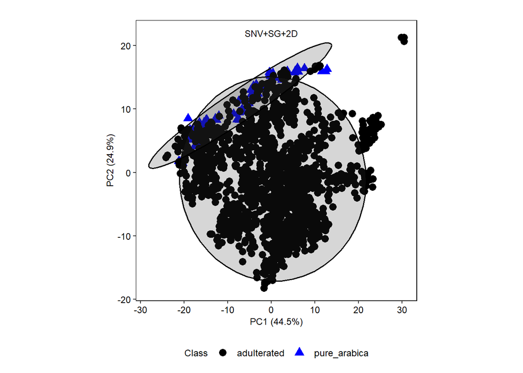

```r
# SNV+SG+1D spectra PCA Plot

Pcs_hsi_snv_sg_2d %>%
  ggplot(mapping = aes(x = PC1, y = PC2,
                       shape = as.factor(binary_class), color = binary_class)) +
  geom_point(size=3) +
  labs(x = "PC1 (44.5%)", y = "PC2 (24.9%)",
       title = "",shape = "Class", color = "Class") +
  theme_bw() +
  theme(
    panel.border = element_rect(color = 'black', fill = NA),
    panel.grid = element_blank(),
    axis.text.x = element_text(color = 'black', size = 9),
    axis.text.y = element_text(color = 'black', size = 9),
    aspect.ratio = 1,
    axis.title.x = element_text(size = 9),
    axis.title.y = element_text(size = 9),
    plot.title = element_text(size = 9, hjust = 0.5),
    legend.title = element_text(size = 9),
    legend.text = element_text(size = 9),
    legend.position = "bottom"
  ) +
  stat_ellipse(aes(group = binary_class),
               level = 0.95,
               geom = "polygon", alpha = 0.2,
               color = 'black', linewidth = 0.6)+
  scale_color_manual(values = c("pure_arabica" = "blue", "adulterated" = "black")) +
   annotate("text", x = 0, y = 22, label = "SNV+SG+2D", size = 3, color = "black")
```

#### Check Important variables contributing to PC1 and PC2 for HSI SNV+SG+2nd Derivative Spectra

```r
# Let us extract the loadings from the PCA
loadings <- pca_snv_sg_2d$var$coord

# Sort the loadings for PC1 and PC2
top_PC1 <- head(sort(abs(loadings[, 1]), decreasing = TRUE), 10) # Top 10 for PC1
top_PC2 <- head(sort(abs(loadings[, 2]), decreasing = TRUE), 10)  # Top 10 for PC2

# Combine into a data frame for easy viewing
top_PC1 <- as.data.frame(top_PC1)
top_PC2 <- as.data.frame(top_PC2)

# Display the top contributing variables
kable(top_PC1)
```

|  | top_PC1 |
| --- | --- |
| X1333.219971 | 0.9605254 |
| X1224.369995 | 0.9525710 |
| X1252.410034 | 0.9511852 |
| X1255.920044 | 0.9507312 |
| X1336.73999 | 0.9484054 |
| X1220.869995 | 0.9424500 |
| X973.650024 | 0.9398907 |
| X1248.900024 | 0.9390240 |
| X1199.869995 | 0.9369854 |
| X1259.420044 | 0.9369443 |

```r
kable(top_PC2)
```

|  | top_PC2 |
| --- | --- |
| X1424.920044 | 0.9637522 |
| X1421.390015 | 0.9494860 |
| X1287.51001 | 0.9397534 |
| X1283.98999 | 0.9335110 |
| X1389.609985 | 0.9235275 |
| X1291.02002 | 0.9210477 |
| X1305.079956 | 0.9109596 |
| X1308.589966 | 0.9091320 |
| X1294.530029 | 0.9076710 |
| X1298.050049 | 0.9057625 |

- The variance in **PC1** is largely contributed by wavelengths regions around **1220-1259 nm** and **1333-1336 nm**, while regions **1287 - 1308 nm** and **1389 - 1424 nm** contribute to PC2.

#### K-Means Clustering: SNV+SG+2nd Derivative Spectra

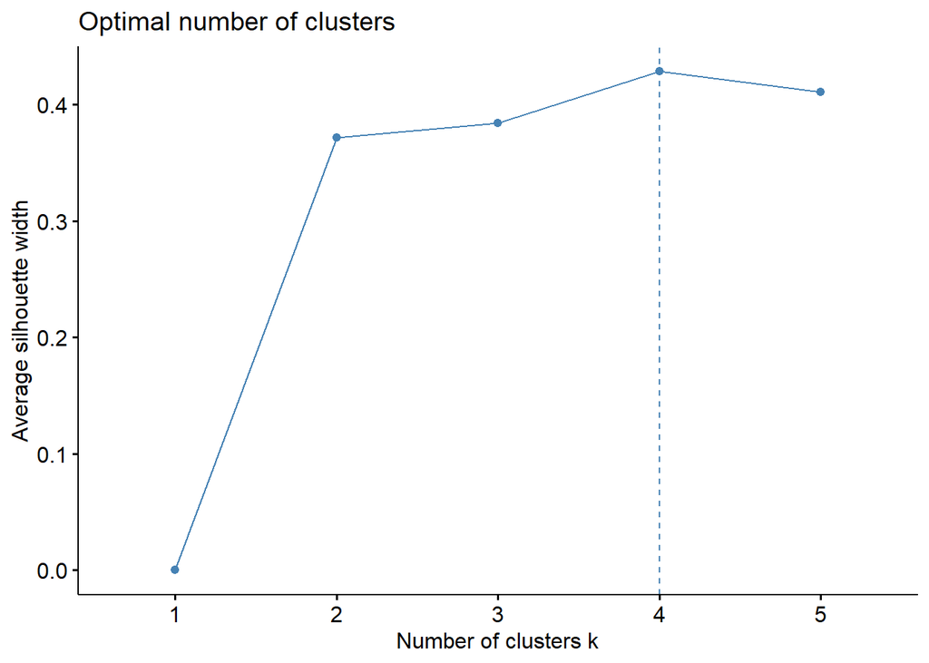

```r
# Use PCA reduced data to first determine the number of clusters  by silhouette method

# optimal number of clusters for HSI
snv_sg_2d_clust<-fviz_nbclust(Pcs_hsi_snv_sg_2d[,c(6,7)],
                        kmeans, method = "silhouette", k.max=5)

print(snv_sg_2d_clust) #determine the number of clusters
```

```r
# Perform K-Means Classification using the optimal number of clusters
snv_sg_2d_kmeans <- kmeans(Pcs_hsi_snv_sg_2d[,c(6,7)], centers = 2, iter.max = 10, nstart = 25)
snv_sg_2d_clusters <- as.factor(snv_sg_2d_kmeans$cluster) # Extract clusters
```

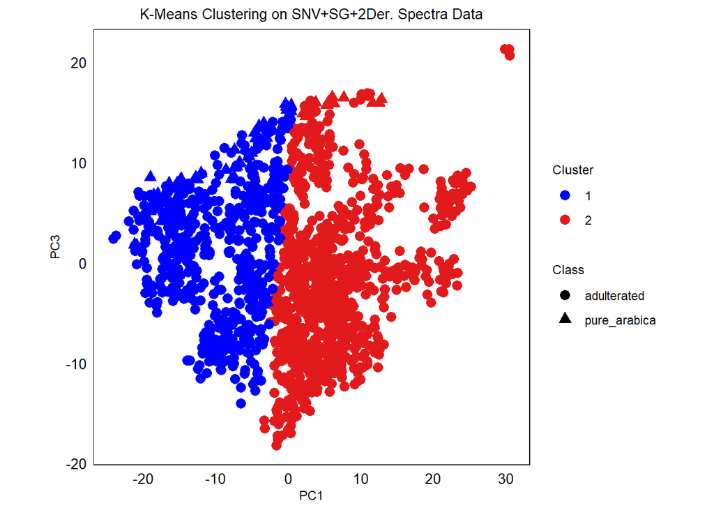

```r
# Add the cluster assignments to the data frame
Pcs_hsi_snv_sg_2d$Cluster <- snv_sg_2d_clusters

# Visualize the clusters
ggplot(Pcs_hsi_snv_sg_2d, aes(x = PC1, y = PC2, color = Cluster, shape = as.factor(binary_class))) +
  geom_point(size = 3) +
  labs(x = "PC1", y = "PC3", title = "K-Means Clustering on SNV+SG+2Der. Spectra Data", shape = 'Class') +
 scale_color_manual(values = c("blue", "#e31a1c",  "#33a02c",  "#6a3d9a")) +
  theme_minimal() +
  theme(panel.border = element_rect(color = 'black', fill = NA),
        panel.grid = element_blank(),
        axis.text.x = element_text(color = 'black', size = 10),
        axis.text.y = element_text(color = 'black', size = 10),
        aspect.ratio = 1,
        axis.title.x = element_text(size = 9),
        axis.title.y = element_text(size = 9),
        legend.title = element_text(size = 9),
        plot.title = element_text(size = 10, hjust = 0.5))
```

#### Confusion Matrix - SNV+SG+2D Spectra

```r
# Create a confusion matrix
cfmatrix_snv_sg_2d<-confusionMatrix(as.factor(snv_sg_2d_clusters),as.factor(class_k))

cfmatrix_snv_sg_2d #display the confusion matrix
```

```
Confusion Matrix and Statistics

          Reference
Prediction   1   2
         1 535  60
         2 859  15

               Accuracy : 0.3744
                 95% CI : (0.3496, 0.3997)
    No Information Rate : 0.9489
    P-Value [Acc > NIR] : 1

                  Kappa : -0.0689

 Mcnemar's Test P-Value : <2e-16

            Sensitivity : 0.38379
            Specificity : 0.20000
         Pos Pred Value : 0.89916
         Neg Pred Value : 0.01716
             Prevalence : 0.94894
         Detection Rate : 0.36419
   Detection Prevalence : 0.40504
      Balanced Accuracy : 0.29189

       'Positive' Class : 1
```

```r
kable(cfmatrix_snv_sg_2d$byClass)
```

|  | x |
| --- | --- |
| Sensitivity | 0.3837877 |
| Specificity | 0.2000000 |
| Pos Pred Value | 0.8991597 |
| Neg Pred Value | 0.0171625 |
| Precision | 0.8991597 |
| Recall | 0.3837877 |
| F1 | 0.5379588 |
| Prevalence | 0.9489449 |
| Detection Rate | 0.3641933 |
| Detection Prevalence | 0.4050374 |
| Balanced Accuracy | 0.2918938 |

### Multiplicative Scatter Correction (MSC) Spectral Data

#### PCA Analysis: MSC pre-treated data

```r
pca_msc <- PCA(hsi_msc[,c(6:229)],ncp = 10, graph = FALSE)

pca_msc$eig[1:10,] # Extract the first 5 component eigenvalues
```

```
          eigenvalue percentage of variance cumulative percentage of variance
comp 1  2.126479e+02           94.932097216                          94.93210
comp 2  7.374393e+00            3.292139717                          98.22424
comp 3  2.730568e+00            1.219003475                          99.44324
comp 4  6.332214e-01            0.282688122                          99.72593
comp 5  3.277157e-01            0.146301671                          99.87223
comp 6  1.430937e-01            0.063881102                          99.93611
comp 7  6.218628e-02            0.027761734                          99.96387
comp 8  2.713774e-02            0.012115062                          99.97599
comp 9  1.673640e-02            0.007471605                          99.98346
comp 10 6.475152e-03            0.002890693                          99.98635
```

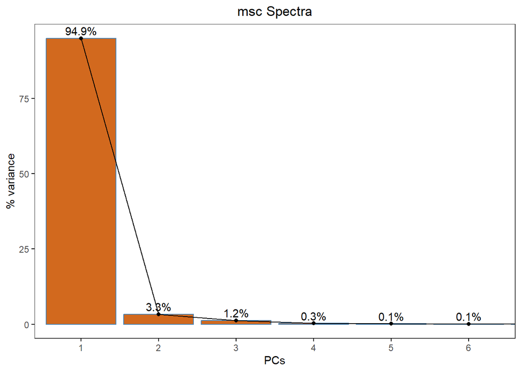

```r
# Scree Plot: Check the number of components to keep

fviz_eig(pca_msc, addlabels = TRUE, ylim = c(0, 95),
         xlim=c(1,6), main = 'msc Spectra',barfill = "chocolate",
         hjust = 0.5,
         ggtheme = theme_bw(),xlab = "PCs", ylab = "% variance")+
  theme(plot.title = element_text(hjust = 0.5))+
  theme(panel.grid = element_blank())
```

```r
# Save the PCs in a new data frame
Pcs_hsi_msc <- as.data.frame(pca_msc$ind$coord[,c(1:10)])
colnames(Pcs_hsi_msc) <- c("PC1","PC2","PC3","PC4","PC5",
                           "PC6","PC7","PC8","PC10")
Pcs_hsi_msc <- cbind(columns, Pcs_hsi_msc) # Bind with the columns from initial data--> with sample details
kable(head(Pcs_hsi_msc))
```

| sample_id | binary_class | three_class | adult_percent | cal_val | PC1 | PC2 | PC3 | PC4 | PC5 | PC6 | PC7 | PC8 | PC10 | NA |
| --- | --- | --- | --- | --- | --- | --- | --- | --- | --- | --- | --- | --- | --- | --- |
| Pure_Arabica_10 | pure_arabica | pure_arabica | 0 | 1 | -11.22488 | -2.882522 | -1.5531461 | 1.3020552 | -0.9074482 | 0.1270824 | 0.1124103 | 0.0838657 | -0.0443802 | 0.0580953 |
| Pure_Arabica_3 | pure_arabica | pure_arabica | 0 | 1 | -21.16959 | -3.479679 | -0.4609370 | 0.7100908 | -1.4716479 | 0.1242450 | 0.2642115 | 0.0796607 | -0.1270277 | 0.1681387 |
| Pure_Arabica_2 | pure_arabica | pure_arabica | 0 | 1 | -13.59825 | -2.266777 | -1.5606186 | 1.7231101 | -1.1806830 | 0.8011181 | 0.0514354 | -0.1217891 | -0.1138434 | -0.0347081 |
| Pure_Arabica_2 | pure_arabica | pure_arabica | 0 | 1 | -13.26080 | -2.430731 | -0.2737347 | 1.9459854 | -1.1936583 | 0.8914602 | 0.1911494 | 0.0690025 | -0.0897213 | -0.0036485 |
| Pure_Arabica_2 | pure_arabica | pure_arabica | 0 | 1 | -14.44702 | -2.496798 | -1.0735596 | 1.5607353 | -0.8799799 | 0.6117986 | 0.1320743 | 0.0584827 | 0.0100348 | 0.0353736 |
| Pure_Arabica_25 | pure_arabica | pure_arabica | 0 | 2 | -15.52722 | -2.872859 | -1.1624711 | 1.6180356 | -1.2436542 | 0.4281130 | 0.3409424 | 0.0032195 | -0.0689576 | 0.1149251 |

```r
#write.csv(Pcs_hsi_msc, file = "pcs_hsi_msc.csv", row.names = FALSE) #save PC data
```

**Insights: PCA-MSC spectral treatment**

- The first two principal components, **PC1 and PC2**, account for the most the variance (**98.2%**).

#### **PCA Plot for MSC Spectra**

[figure not shown]

```r
# msc spectra PCA Plot

Pcs_hsi_msc %>%
  ggplot(mapping = aes(x = PC1, y = PC3,
                       shape = as.factor(binary_class), color = binary_class)) +
  geom_point(size= 3) +
  labs(x = "PC1 (94.9%)", y = "PC2 (3.3%)",
       title = "",shape = "Class", color = "Class") +
  theme_bw() +
  theme(
    panel.border = element_rect(color = 'black', fill = NA),
    panel.grid = element_blank(),
    axis.text.x = element_text(color = 'black', size = 9),
    axis.text.y = element_text(color = 'black', size = 9),
    aspect.ratio = 1,
    axis.title.x = element_text(size = 9),
    axis.title.y = element_text(size = 9),
    plot.title = element_text(size = 9, hjust = 0.5),
    legend.title = element_text(size = 9),
    legend.text = element_text(size = 9),
    legend.position = "bottom"
  ) +
  scale_color_manual(values = c("pure_arabica" = "blue", "adulterated" = "black")) +
   annotate("text", x = 0, y = 6, label = "MSC Spectra", size = 3, color = "black")
```

#### Check Important variables contributing to PC1 and PC2 for HSI msc Spectra

```r
# Let us extract the loadings from the PCA
loadings <- pca_msc$var$coord

# Sort the loadings for PC1 and PC2
top_PC1 <- head(sort(abs(loadings[, 1]), decreasing = TRUE), 10) # Top 10 for PC1
top_PC2 <- head(sort(abs(loadings[, 2]), decreasing = TRUE), 10)  # Top 10 for PC2

# Combine into a data frame for easy viewing
top_PC1 <- as.data.frame(top_PC1)
top_PC2 <- as.data.frame(top_PC2)

# Display the top contributing variables
#kable(top_PC1)
kable(top_PC2)
```

|  | top_PC2 |
| --- | --- |
| X1343.780029 | 0.6534117 |
| X1720.22998 | 0.5244273 |
| X1716.650024 | 0.5124793 |
| X1407.26001 | 0.4991740 |
| X1713.069946 | 0.4987888 |
| X1410.790039 | 0.4955730 |
| X1709.48999 | 0.4833175 |
| X1403.72998 | 0.4821471 |
| X1340.26001 | 0.4776650 |
| X1414.319946 | 0.4737191 |

#### K-Means Clustering: MSC Spectra

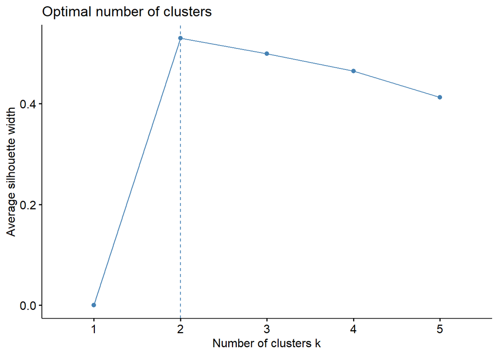

```r
# Use PCA reduced data to first determine the number of clusters  by silhouette method

# optimal number of clusters for HSI
msc_clust<-fviz_nbclust(Pcs_hsi_msc[,c(6,7)],
                        kmeans, method = "silhouette", k.max=5)

print(msc_clust) #determine the number of clusters
```

```r
# Perform K-Means Classification using the optimal number of clusters
msc_kmeans <- kmeans(Pcs_hsi_msc[,c(6,7)],centers = 2,iter.max = 10,nstart = 25)
msc_clusters <- as.factor(msc_kmeans$cluster) # Extract clusters
```

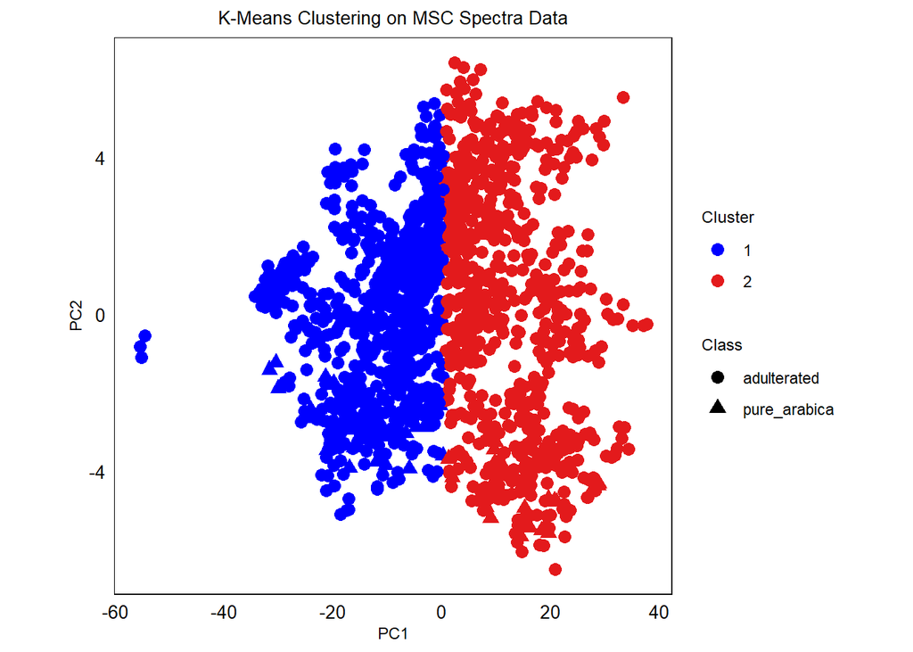

```r
# Add the cluster assignments to the data frame
Pcs_hsi_msc$Cluster <- msc_clusters

# Visualize the clusters
ggplot(Pcs_hsi_msc, aes(x = PC1, y = PC2, color = Cluster, shape = as.factor(binary_class))) +
  geom_point(size = 3) +
  labs(x = "PC1", y = "PC2", title = "K-Means Clustering on MSC Spectra Data", shape = 'Class') +
 scale_color_manual(values = c("blue", "#e31a1c")) +
  theme_minimal() +
  theme(panel.border = element_rect(color = 'black', fill = NA),
        panel.grid = element_blank(),
        axis.text.x = element_text(color = 'black', size = 10),
        axis.text.y = element_text(color = 'black', size = 10),
        aspect.ratio = 1,
        axis.title.x = element_text(size = 9),
        axis.title.y = element_text(size = 9),
        legend.title = element_text(size = 9),
        plot.title = element_text(size = 10, hjust = 0.5))
```

#### Confusion Matrix - MSC Spectra

```r
# Create a confusion matrix
cfmatrix_msc<-confusionMatrix(as.factor(msc_clusters),as.factor(class_k))

cfmatrix_msc #display the confusion matrix
```

```
Confusion Matrix and Statistics

          Reference
Prediction   1   2
         1 720  46
         2 674  29

               Accuracy : 0.5099
                 95% CI : (0.484, 0.5357)
    No Information Rate : 0.9489
    P-Value [Acc > NIR] : 1

                  Kappa : -0.0195

 Mcnemar's Test P-Value : <2e-16

            Sensitivity : 0.51650
            Specificity : 0.38667
         Pos Pred Value : 0.93995
         Neg Pred Value : 0.04125
             Prevalence : 0.94894
         Detection Rate : 0.49013
   Detection Prevalence : 0.52144
      Balanced Accuracy : 0.45158

       'Positive' Class : 1
```

```r
kable(cfmatrix_msc$byClass)
```

|  | x |
| --- | --- |
| Sensitivity | 0.5164993 |
| Specificity | 0.3866667 |
| Pos Pred Value | 0.9399478 |
| Neg Pred Value | 0.0412518 |
| Precision | 0.9399478 |
| Recall | 0.5164993 |
| F1 | 0.6666667 |
| Prevalence | 0.9489449 |
| Detection Rate | 0.4901293 |
| Detection Prevalence | 0.5214432 |
| Balanced Accuracy | 0.4515830 |

### Multiplicative Scatter Correction, Savitzky_Golay and 1st Derivative Spectral Data

#### PCA Analysis: MSC+SG+1D pre-treated data

```r
pca_msc_sg_1d <- PCA(hsi_msc_1d[,c(6:229)],ncp = 15, graph = FALSE)

pca_msc_sg_1d$eig[1:15,] # Extract the first 5 component eigenvalues
```

```
          eigenvalue percentage of variance cumulative percentage of variance
comp 1  113.23745897            50.55243704                          50.55244
comp 2   66.03912396            29.48175177                          80.03419
comp 3   16.38064826             7.31278940                          87.34698
comp 4    9.54826909             4.26262013                          91.60960
comp 5    7.37898827             3.29419119                          94.90379
comp 6    5.83895934             2.60667828                          97.51047
comp 7    2.40931519             1.07558714                          98.58605
comp 8    0.94207295             0.42056828                          99.00662
comp 9    0.88006189             0.39288477                          99.39951
comp 10   0.28062795             0.12528034                          99.52479
comp 11   0.23669423             0.10566707                          99.63046
comp 12   0.15959145             0.07124618                          99.70170
comp 13   0.12805712             0.05716836                          99.75887
comp 14   0.07727134             0.03449613                          99.79337
comp 15   0.06335689             0.02828433                          99.82165
```

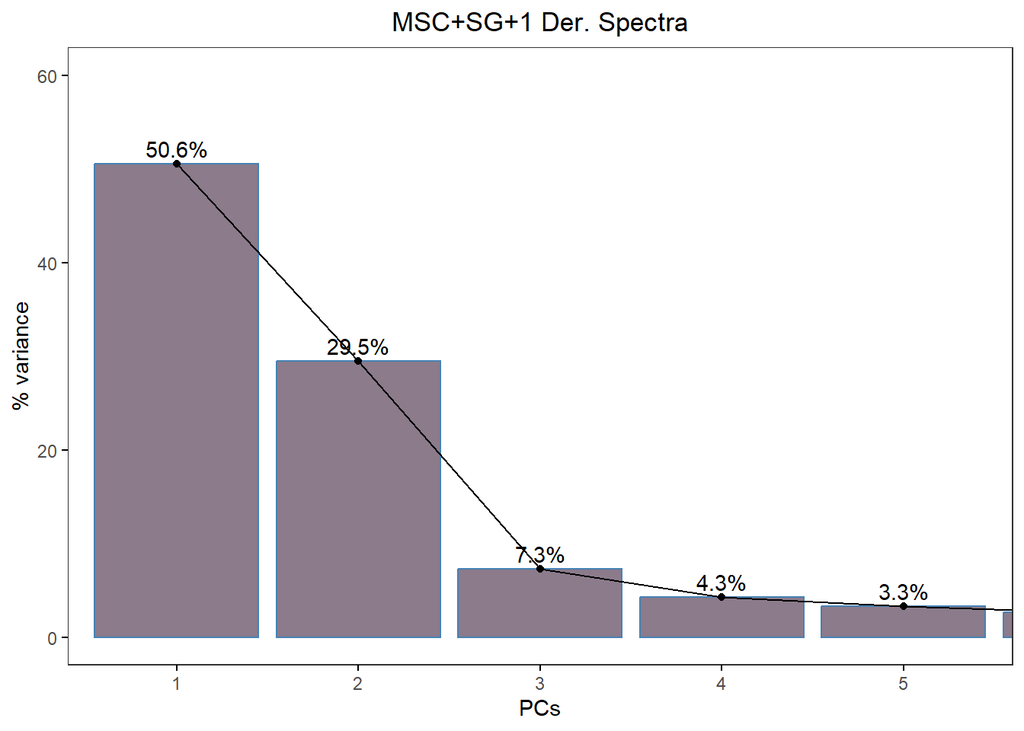

```r
# Scree Plot: Check the number of components to keep

fviz_eig(pca_msc_sg_1d, addlabels = TRUE, ylim = c(0, 60),
         xlim=c(1,5), main = 'MSC+SG+1 Der. Spectra',barfill = "thistle4",
         hjust = 0.5,
         ggtheme = theme_bw(),xlab = "PCs", ylab = "% variance")+
  theme(plot.title = element_text(hjust = 0.5))+
  theme(panel.grid = element_blank())
```

```r
# Save the PCs in a new data frame
Pcs_hsi_msc_sg_1d <- as.data.frame(pca_msc_sg_1d$ind$coord[,c(1:15)])
colnames(Pcs_hsi_msc_sg_1d) <- c("PC1","PC2","PC3","PC4","PC5",
                                 "PC6","PC7","PC8","PC9","PC10",
                                 "PC11","PC12","PC13","PC14","PC15")
Pcs_hsi_msc_sg_1d <- cbind(columns, Pcs_hsi_msc_sg_1d) # Bind with the columns from initial data--> with sample details
kable(head(Pcs_hsi_msc_sg_1d))
```

| sample_id | binary_class | three_class | adult_percent | cal_val | PC1 | PC2 | PC3 | PC4 | PC5 | PC6 | PC7 | PC8 | PC9 | PC10 | PC11 | PC12 | PC13 | PC14 | PC15 |
| --- | --- | --- | --- | --- | --- | --- | --- | --- | --- | --- | --- | --- | --- | --- | --- | --- | --- | --- | --- |
| Pure_Arabica_10 | pure_arabica | pure_arabica | 0 | 1 | 8.458034 | -8.445949 | 9.045044 | 3.911966 | 0.0226065 | 0.1357246 | -0.1005159 | -0.0031570 | -0.2742050 | -0.7336052 | -0.2006985 | -0.0312381 | -0.0978622 | 0.3081709 | 0.1925836 |
| Pure_Arabica_3 | pure_arabica | pure_arabica | 0 | 1 | 17.144920 | -10.099217 | 8.065836 | 5.548340 | 2.1592085 | -2.9398757 | -2.2613815 | 1.2775252 | -0.2413820 | -0.7268082 | -0.3922241 | -0.3474878 | -0.7992991 | -0.0097419 | 0.1280817 |
| Pure_Arabica_2 | pure_arabica | pure_arabica | 0 | 1 | 10.283693 | -7.672246 | 12.136694 | 3.961296 | -2.4936476 | -2.2621794 | -0.5760467 | 0.4728807 | -0.9002910 | -0.0150855 | -0.0889445 | -0.0290660 | 0.3590722 | 0.0516869 | 0.2824588 |
| Pure_Arabica_2 | pure_arabica | pure_arabica | 0 | 1 | 10.275313 | -6.561373 | 12.015279 | 5.246912 | -2.7508025 | -2.9234694 | -0.6383525 | -0.4009796 | -1.1766382 | -0.1079325 | -0.2449240 | -0.4655714 | 0.3434772 | -0.0990182 | 0.6281334 |
| Pure_Arabica_2 | pure_arabica | pure_arabica | 0 | 1 | 11.166464 | -7.654687 | 10.446477 | 3.414268 | -2.0105879 | -1.4639056 | -0.4977181 | -0.5961695 | -0.6159717 | -0.4030621 | 0.1897555 | -0.2589664 | -0.0566471 | 0.0424745 | 0.4182441 |
| Pure_Arabica_25 | pure_arabica | pure_arabica | 0 | 2 | 12.023117 | -8.334828 | 10.974346 | 5.513674 | -1.2472368 | -2.6332644 | 0.0545832 | 0.9583076 | -1.9561298 | -0.2286070 | -0.7305678 | -0.1652848 | 0.6731059 | -0.4391059 | -0.1331746 |

```r
#write.csv(Pcs_hsi_msc_sg_1d, file = "pcs_hsi_msc_sg_1d.csv", row.names = FALSE) #save PC data
```

#### **PCA Plot for msc+SG+1D Spectra**

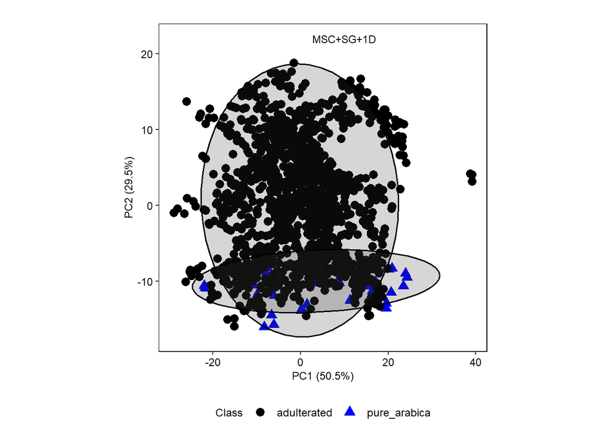

```r
# MSC+SG+1D spectra PCA Plot

Pcs_hsi_msc_sg_1d %>%
  ggplot(mapping = aes(x = PC1, y = PC2,
                       shape = as.factor(binary_class), color = binary_class)) +
  geom_point(size=3) +
  labs(x = "PC1 (50.5%)", y = "PC2 (29.5%)",
       title = "",shape = "Class", color = "Class") +
  theme_bw() +
  theme(
    panel.border = element_rect(color = 'black', fill = NA),
    panel.grid = element_blank(),
    axis.text.x = element_text(color = 'black', size = 9),
    axis.text.y = element_text(color = 'black', size = 9),
    aspect.ratio = 1,
    axis.title.x = element_text(size = 9),
    axis.title.y = element_text(size = 9),
    plot.title = element_text(size = 9, hjust = 0.5),
    legend.title = element_text(size = 9),
    legend.text = element_text(size = 9),
    legend.position = "bottom"
  ) +
  stat_ellipse(aes(group = binary_class),
               level = 0.95,
               geom = "polygon", alpha = 0.2,
               color = 'black', linewidth = 0.6)+
  scale_color_manual(values = c("pure_arabica" = "blue", "adulterated" = "black")) +
   annotate("text", x = 10, y = 22, label = "MSC+SG+1D", size = 3, color = "black")
```

#### Check Important variables contributing to PC1 and PC2 for HSI msc+SG+1st Derivative Spectra

```r
# Let us extract the loadings from the PCA
loadings <- pca_msc_sg_1d$var$coord

# Sort the loadings for PC1 and PC2
top_PC1 <- head(sort(abs(loadings[, 1]), decreasing = TRUE), 10) # Top 10 for PC1
top_PC2 <- head(sort(abs(loadings[, 2]), decreasing = TRUE), 10)  # Top 10 for PC2

# Combine into a data frame for easy viewing
top_PC1 <- as.data.frame(top_PC1)
top_PC2 <- as.data.frame(top_PC2)

# Display the top contributing variables
#kable(top_PC1)
kable(top_PC2)
```

|  | top_PC2 |
| --- | --- |
| X1570.310059 | 0.9759730 |
| X1573.869995 | 0.9735652 |
| X1566.75 | 0.9715574 |
| X1563.199951 | 0.9647711 |
| X1559.640015 | 0.9574164 |
| X1577.430054 | 0.9541198 |
| X1556.089966 | 0.9494329 |
| X1552.530029 | 0.9425514 |
| X1548.97998 | 0.9381158 |
| X1545.420044 | 0.9332511 |